# Introducción a R

26 de mayo de 2020

## ¿Quien soy?

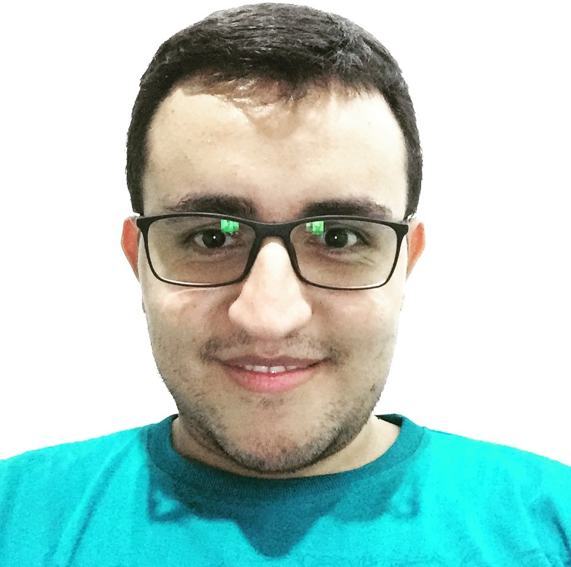

- William Hoyos
- Estudiante doctoral (EAFIT)
- Intereses:
  - Predicción de Enfermedades con Inteligencia Artificial
- Contacto:
  - wshoyosm@eafit.edu.co
  - Twitter: @whoyos21

## Descarga R y RStudio

## Descarga de R

- Descarga de R https://ftp.osuosl.org/pub/cran/
- Click “Download R for (Mac) OS X” or “Download R for Windows”
- Descarga la última versión

[figure not shown]

## Descarga de RStudio

- Descarga de RStudio
- https://rstudio.com/products/rstudio/download/
- Click “Download”
- Descarga la última versión

[figure not shown]

## Estructura de R y RStudio

## Estructura de R

[figure not shown]

## Estructura de RStudio

[figure not shown]

## Los paquetes: la principal herramienta de R

## Paquetes

- Paquete base de R
- Conjunto de funciones para realizar una tarea específica
- También llamadas librerías

[figure not shown]

## Las funciones

## Funciones en R

- Una función permite automatizar tareas de forma mas poderosa
- Vienen en los paquetes
- Pueden ser creadas por cualquier mortal
- Ejemplos:

Función que instala paquetes:

```r
#install.packages("ggplot2") #Ojo las comillas
```

Función que carga el paquete a R

```r
#library(ggplot2) #No es necesario comillas
```

## R como una calculadora

## R como una calculadora

```r
5 + 7 #Pulsamos Enter y muestra el resultado
```

```
## [1] 12
```

```r
pi
```

```
## [1] 3.141593
```

```r
exp(2)
```

```
## [1] 7.389056
```

## R como una calculadora

```r
5 + 7.5 #Suma
```

```
## [1] 12.5
```

```r
12 - 5.1 #Diferencia
```

```
## [1] 6.9
```

```r
7 * 5 #Multiplicación
```

```
## [1] 35
```

```r
18 / 6 #División
```

```
## [1] 3
```

## R como una calculadora

Expresión matemática: *2(3+5)*

```r
2 * (3 + 5)
```

```
## [1] 16
```

Funciones numéricas

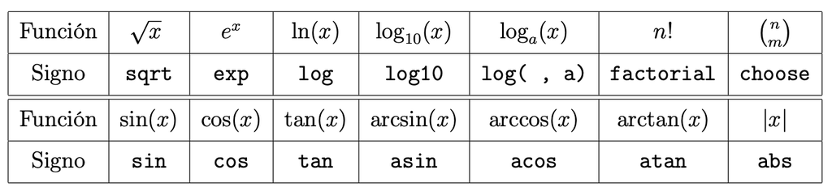

## Objetos en R

## Objetos en R

- R almacena los datos como objetos
- Se usa el símbolo `<-` para asignar
- Ejemplos:

```r
x <- 5;x
```

```
## [1] 5
```

```r
y <- 7;y
```

```
## [1] 7
```

```r
z <- exp(x);z
```

```
## [1] 148.4132
```

## Tipos de datos

## Tipos de datos

- `logical` (lógicos: TRUE = verdadero; FALSE = falso)

```r
25 > 5
```

```
## [1] TRUE
```

```r
class(25 > 5) #¿De que clase es el dato resultante?
```

```
## [1] "logical"
```

```r
class(7)
```

```
## [1] "numeric"
```

## Tipos de datos

- `numeric` (números reales)

```r
class(7.5)
```

```
## [1] "numeric"
```

- `character` (palabras)

```r
class("Hola mundo")
```

```
## [1] "character"
```

## Estructuras de datos

## Vectores

- Conjunto de datos del mismo tipo
- Una dimensión
- Nombres de 5 personas
  - “Alvaro”, “Alicia”, “Pedro”, “Jose”, “Martha”

```r
#Función c() que combina
nombres <- c("Alvaro", "Alicia", "Pedro", "Jose", "Martha")
nombres
```

```
## [1] "Alvaro" "Alicia" "Pedro"  "Jose"   "Martha"
```

```r
class(nombres)
```

```
## [1] "character"
```

## Vectores

- Edades de las 5 personas
  - 32, 12, 54, 76, 34

```r
#Función c() que combina
edades <- c(32, 12, 54, 76, 34)
edades
```

```
## [1] 32 12 54 76 34
```

```r
class(edades)
```

```
## [1] "numeric"
```

## Vectores

- Creación de vectores de secuencias

```r
#Secuencia desde el 0 hasta el 50
seq(from = 0, to = 50)
```

```
##  [1]  0  1  2  3  4  5  6  7  8  9 10 11 12 13 14 15 16 17 18 19 20 21 22 23 24
## [26] 25 26 27 28 29 30 31 32 33 34 35 36 37 38 39 40 41 42 43 44 45 46 47 48 49
## [51] 50
```

```r
#Secuencia del 0 hasta el 50, de 10 en 10
seq(from = 0, to = 50, by = 10)
```

```
## [1]  0 10 20 30 40 50
```

## Operaciones con vectores

Suma de vectores

```r
vector1 <- c(1, 2, 3, 4, 5)
vector2 <- c(5, 10, 15, 20, 25)

vector3 <- vector1 + vector2
vector3
```

```
## [1]  6 12 18 24 30
```